# re_stepwise

Valentin Lanz

2025-04-07

In this exercise, I am going to try to develop a stepwise regression algorithm.

```r
library(dplyr)
library(ggplot2)


#read data
url_fluxes <- "https://raw.githubusercontent.com/geco-bern/agds_book/refs/heads/main/book/data/df_for_stepwise_regression.csv"

half_hourly_fluxes <- read.table(
  url_fluxes,
  header = TRUE,
  sep = ","
)
```

## Single predictor models

```r
# numerical variables only, remove NA
clean_fluxes <- half_hourly_fluxes |>
  dplyr::select(-starts_with("TIMESTAMP",), -"siteid") |>
  tidyr::drop_na()


#create data frame for results of the bivariate model analysis
bivar_results = data.frame(predictor = character(), R2 = numeric(), AIC = numeric())


#vector containing names of possible predictor variables
predictor_vars <- colnames(clean_fluxes)
predictor_vars <- predictor_vars[predictor_vars != "GPP_NT_VUT_REF"]


#create all bivariate models using GPP and a different predictor variable in every iteration
for (pred_var in predictor_vars) {

  linear_model <- lm(as.formula(paste("GPP_NT_VUT_REF ~ ", pred_var)), data = clean_fluxes)

  current_R2 <- (summary(linear_model)$r.squared)  #calculate R^2 of the model
  current_AIC <- extractAIC(linear_model)[2]      #calculate AIC of the model


  #add row with predictor name, R2 and AIC to the results dataframe
  bivar_results <- rbind(bivar_results, data.frame(predictor = pred_var, R2 = current_R2,
                                             AIC = current_AIC))

}


#sort results, highest R2 first
bivar_results_sorted <- bivar_results |> dplyr::arrange(desc(R2))

knitr::kable(bivar_results_sorted, align = "c")
```

| predictor | R2 | AIC |
| --- | --- | --- |
| PPFD_IN | 0.3627837 | 18738.19 |
| SW_IN_F_MDS | 0.3504158 | 18920.69 |
| SW_IN_F | 0.3503274 | 18921.99 |
| TA_F_MDS | 0.2766429 | 19941.97 |
| TA_F | 0.2766277 | 19942.17 |
| VPD_F | 0.1179701 | 21824.85 |
| LW_IN_F_MDS | 0.1163707 | 21842.05 |
| LW_IN_F | 0.1142586 | 21864.71 |
| VPD_F_MDS | 0.1115091 | 21894.14 |
| CO2_F_MDS | 0.0501273 | 22528.37 |
| WS_F | 0.0122956 | 22899.17 |
| P_F | 0.0029678 | 22988.41 |
| PA_F | 0.0002874 | 23013.89 |
| USTAR | 0.0000309 | 23016.33 |

The above table shows the best predictors in descending order. High R<sup>2</sup> and low AIC show that a predictor is accurate.

Visualise the results in a bar plot:

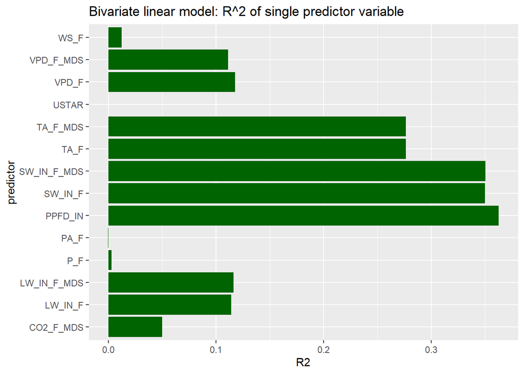

```r
#bar plot R^2 of the predictors
bp_bivar <- ggplot(data = bivar_results_sorted, aes(x = predictor, y = R2)) +
  geom_bar(stat = "identity", fill = "darkgreen") +
  coord_flip() +
  labs(title = "Bivariate linear model: R^2 of single predictor variable")


bp_bivar
```

**Discussion of the Results:**

PPFD_IN has the strongest correlation with GPP_NT_VUT_REF. In other words, gross primary production depends the most on the density of incoming photosynthetic photon fluxes. SW_IN_F and SW_IN_F_MDS have a fairly strong influence too. Both of these variables stand for incoming shortwave radiation. Next is air temperature, represented by the variables TA_F and TA_F_MDS, with an R<sup>2</sup> of 0.277. Vapor pressure deficit (VPD) and incoming longwave radiation (LW_IN) have a smaller effect on GPP. The fraction of CO2 is even less important. Precipitation (P_F) and air pressure (PA_F) have almost no correlation.

## Multivariate models

```r
#select the model with the highest R2 and take its AIC
highest_r2_1pred <- bivar_results_sorted |> slice(1)
aic_1pred <- highest_r2_1pred[3]



#remove the predictor used before from the vector of predictor names so that it is not used again
predictor_vars_multivar <- predictor_vars[predictor_vars != highest_r2_1pred$predictor]




#increase the number of predictors now
#do this by defining a vector to which we will add the most accurate predictor for every iteration
chosen_predictors <- c(highest_r2_1pred[1])


#create data frame to store all multivariate models of one iteration
multivariate_results <- data.frame(predictor = character(), R2_adj = numeric(), AIC = numeric())



#create tibble to store the best model of every iteration
best_model_p_predictors <- tibble(p = numeric(), predictors = vector(), AIC = numeric())



aic_p_minus_1 <- Inf            #set aic of model with zero predictors to Inf to guarantee that
                                #the aic_p will be smaller and the while condition will be true

aic_p <- aic_1pred              #define aic of model with p predictors


#set up while loop that runs as long as the aic of the best model with p predictors
# is better (smaller) than the aic of the best model with p-1 predictors

while(aic_p < aic_p_minus_1) {



#iterate over remaining predictor variables and use them together with
# chosen predictors to fit multivariate model


  for (pred_var in predictor_vars_multivar) {

     multivariate_lm <- lm(as.formula(paste("GPP_NT_VUT_REF ~ ",
      paste(c(chosen_predictors, pred_var), collapse = " + "))), data = clean_fluxes)


     multivariate_R2_adj <- (summary(multivariate_lm)$adj.r.squared)  #calculate adjusted R^2
     multivariate_AIC <- extractAIC(multivariate_lm)[2]      #calculate AIC of the model


     #add row with predictor name, R2 and AIC to the multivariate results dataframe
     multivariate_results <- rbind(multivariate_results,
                                   data.frame(predictor = pred_var,
                                              R2_adj = multivariate_R2_adj,
                                              AIC = multivariate_AIC))

}




  #sort results, highest R2 first
  multivariate_results_sorted <- multivariate_results |> dplyr::arrange(desc(R2_adj))
  multivariate_results_sorted


  #select the multivariate model with the highest R2
  multivar_model_highest_r2 <- multivariate_results_sorted |> slice(1)




  #name of the best predictor
  best_predictor <- as.character(multivar_model_highest_r2$predictor[1])



  #update the two AIC variables that are to be compared
  aic_p_minus_1 <- aic_p
  aic_p <- multivar_model_highest_r2[3]



  #remove the best predictor from the vector of predictors not yet used
  predictor_vars_multivar <- predictor_vars_multivar[predictor_vars_multivar != best_predictor]



  #add the best predictor to the list of predictors used
  chosen_predictors <- append(chosen_predictors, best_predictor)


  #add best model to the tibble
  best_model_p_predictors <- rbind(best_model_p_predictors, tibble(p = length(chosen_predictors), predictors = paste(chosen_predictors, collapse = " + "), AIC = aic_p))

  #reconstruct the best model
  best_model <-  lm(as.formula(paste("GPP_NT_VUT_REF ~ ",
      paste(chosen_predictors, collapse = " + "))), data = clean_fluxes)



   #print out the formula of the current best model
  print(paste("Best Model of this iteration: ", format(formula(best_model))))
  print(paste("Number of predictors: ", length(chosen_predictors)))
  print(paste("AIC: ", aic_p))



  #reset the results table so it will be empty when the next for loops starts
  multivariate_results <- data.frame(predictor = character(), R2_adj = numeric(), AIC = numeric())

}
```

```
## [1] "Best Model of this iteration:  GPP_NT_VUT_REF ~ PPFD_IN + LW_IN_F"
## [1] "Number of predictors:  2"
## [1] "AIC:  17557.0419967694"
## [1] "Best Model of this iteration:  GPP_NT_VUT_REF ~ PPFD_IN + LW_IN_F + VPD_F"
## [1] "Number of predictors:  3"
## [1] "AIC:  16609.4981228948"
## [1] "Best Model of this iteration:  GPP_NT_VUT_REF ~ PPFD_IN + LW_IN_F + VPD_F + TA_F_MDS"
## [1] "Number of predictors:  4"
## [1] "AIC:  16425.5192285584"
## [1] "Best Model of this iteration:  GPP_NT_VUT_REF ~ PPFD_IN + LW_IN_F + VPD_F + TA_F_MDS + WS_F"
## [1] "Number of predictors:  5"
## [1] "AIC:  16326.4170586552"
## [1] "Best Model of this iteration:  GPP_NT_VUT_REF ~ PPFD_IN + LW_IN_F + VPD_F + TA_F_MDS + WS_F + "
## [2] "Best Model of this iteration:      USTAR"
## [1] "Number of predictors:  6"
```

[output cut: 21 more lines]

Notice that the AIC of the last model is poorer than the AIC of the previous one, which uses ten predictors. The last one is still printed out, this is due to the condition of the while loop, which breaks only now that the current model’s AIC (11 predictors) is poorer than the previous model’s AIC.

```r
knitr::kable(best_model_p_predictors)
```

| p | predictors | AIC |
| --- | --- | --- |
| 2 | PPFD_IN + LW_IN_F | 17557.04 |
| 3 | PPFD_IN + LW_IN_F + VPD_F | 16609.50 |
| 4 | PPFD_IN + LW_IN_F + VPD_F + TA_F_MDS | 16425.52 |
| 5 | PPFD_IN + LW_IN_F + VPD_F + TA_F_MDS + WS_F | 16326.42 |
| 6 | PPFD_IN + LW_IN_F + VPD_F + TA_F_MDS + WS_F + USTAR | 16033.31 |
| 7 | PPFD_IN + LW_IN_F + VPD_F + TA_F_MDS + WS_F + USTAR + SW_IN_F | 15962.96 |
| 8 | PPFD_IN + LW_IN_F + VPD_F + TA_F_MDS + WS_F + USTAR + SW_IN_F + P_F | 15928.04 |
| 9 | PPFD_IN + LW_IN_F + VPD_F + TA_F_MDS + WS_F + USTAR + SW_IN_F + P_F + CO2_F_MDS | 15910.80 |
| 10 | PPFD_IN + LW_IN_F + VPD_F + TA_F_MDS + WS_F + USTAR + SW_IN_F + P_F + CO2_F_MDS + PA_F | 15893.35 |
| 11 | PPFD_IN + LW_IN_F + VPD_F + TA_F_MDS + WS_F + USTAR + SW_IN_F + P_F + CO2_F_MDS + PA_F + LW_IN_F_MDS | 15894.45 |

The regression model with 10 predictors has the lowest AIC.

To see how the AIC developed with increasing number of predictors, look at the following plot:

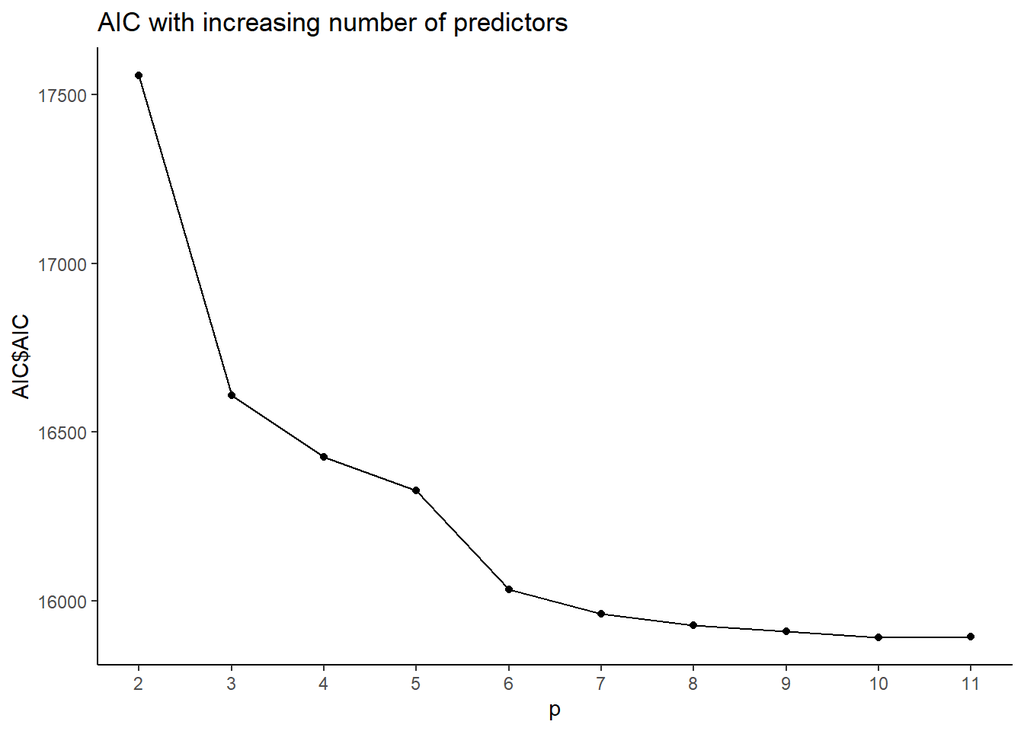

```r
plot_stepwise_aic <- ggplot(data = best_model_p_predictors, aes(x = p, y = AIC$AIC)) +
  geom_point() +
  geom_line() +
  labs(title = "AIC with increasing number of predictors") +
  theme_classic()

plot_stepwise_aic + scale_x_continuous(breaks = seq(1:11))
```

**Discussion of stepwise forward regression**